# Rapport du projet R

Clément Reis

Zihao Guo

Romane Tézé

# I. Introduction

La thyroïde est une glande en forme de papillon, située à la base du cou, qui produit des hormones jouant un rôle important dans le métabolisme énergétique. Lorsque la thyroïde dysfonctionne, elle produit soit un excès d’hormones thyroïdiennes ; on parle alors d’hyperthyroïde, soit elle ne parvient plus à en produire suffisamment, et on parle alors d’hypothyroïde. L’objectif du projet est de créer des dashboard facilitant la visualisation d’un jeu de données sur la thyroïde, et d’en extraire des informations sur les facteurs permettant de diagnostiquer efficacement une maladie de la thyroïde.

# II. Traitement des données

Le dataset brut à notre disposition contient de nombreuses informations relatives à la thyroïde, relevées sur 3 772 patients.

```
## Rows: 3,772
## Columns: 28
## $ ThyroidClass                   <chr> "negative", "negative", "negative", "ne…
## $ patient_age                    <dbl> 41, 23, 46, 70, 70, 18, 59, 80, 66, 68,…
## $ patient_gender                 <dbl> 1, 1, 0, 1, 1, 1, 1, 1, 1, 0, 1, 1, 1, …
## $ presc_thyroxine                <dbl> 0, 0, 0, 1, 0, 1, 0, 0, 0, 0, 0, 1, 0, …
## $ queried_why_on_thyroxine       <dbl> 0, 0, 0, 0, 0, 0, 0, 0, 0, 0, 0, 0, 0, …
## $ presc_anthyroid_meds           <dbl> 0, 0, 0, 0, 0, 0, 0, 0, 0, 0, 0, 0, 0, …
## $ sick                           <dbl> 0, 0, 0, 0, 0, 0, 0, 0, 0, 0, 0, 0, 1, …
## $ pregnant                       <dbl> 0, 0, 0, 0, 0, 0, 0, 0, 0, 0, 0, 0, 0, …
## $ thyroid_surgery                <dbl> 0, 0, 0, 0, 0, 0, 0, 0, 0, 0, 0, 0, 0, …
## $ radioactive_iodine_therapyI131 <dbl> 0, 0, 0, 0, 0, 0, 0, 0, 0, 0, 0, 0, 0, …
## $ query_hypothyroid              <dbl> 0, 0, 0, 0, 0, 0, 0, 0, 0, 0, 0, 0, 0, …
## $ query_hyperthyroid             <dbl> 0, 0, 0, 0, 0, 0, 0, 0, 0, 0, 0, 0, 1, …
## $ lithium                        <dbl> 0, 0, 0, 0, 0, 0, 0, 0, 0, 0, 0, 0, 0, …
## $ goitre                         <dbl> 0, 0, 0, 0, 0, 0, 0, 0, 0, 0, 0, 0, 0, …
## $ tumor                          <dbl> 0, 0, 0, 0, 0, 0, 0, 0, 1, 0, 1, 0, 0, …
## $ hypopituitarism                <dbl> 0, 0, 0, 0, 0, 0, 0, 0, 0, 0, 0, 0, 0, …
## $ psych_condition                <dbl> 0, 0, 0, 0, 0, 0, 0, 0, 0, 0, 0, 0, 0, …
## $ TSH_measured                   <dbl> 1.0, 1.0, 1.0, 1.0, 1.0, 1.0, 0.0, 1.0,…
## $ TSH_reading                    <dbl> 1.30, 4.10, 0.98, 0.16, 0.72, 0.03, NA,…
## $ T3_measured                    <dbl> 1.0, 1.0, 0.0, 1.0, 1.0, 0.0, 0.0, 1.0,…
## $ T3_reading                     <dbl> 2.5, 2.0, NA, 1.9, 1.2, NA, NA, 0.6, 2.…
## $ T4_measured                    <dbl> 1, 1, 1, 1, 1, 1, 1, 1, 1, 1, 1, 1, 1, …
## $ T4_reading                     <dbl> 125, 102, 109, 175, 61, 183, 72, 80, 12…
## $ thyrox_util_rate_T4U_measured  <dbl> 1.00, 0.00, 1.00, 0.00, 1.00, 1.00, 1.0…
## $ thyrox_util_rate_T4U_reading   <dbl> 1.14, NA, 0.91, NA, 0.87, 1.30, 0.92, 0…
## $ FTI_measured                   <dbl> 1, 0, 1, 0, 1, 1, 1, 1, 1, 1, 1, 1, 1, …
## $ FTI_reading                    <dbl> 109, NA, 120, NA, 70, 141, 78, 115, 132…
## $ ref_src                        <chr> "SVHC", "other", "other", "other", "SVI…
```

Les patients dont la thyroïde a été diagnostiquée malade sont indiqués par le label *sick* dans la colonne **ThyroidClass** (à noter que la variable dans le dataset original était appelée **ThryroidClass**. Nous l’avons modifiée pour **ThyroidClass** dans notre dataset et nous utiliserons ce nom dans tout le rapport.). Dans le cas contraire, c’est le label *negative* qui s’affiche. Ces données ne sont pas toujours en cohérence avec les données de la colonne **sick**, qui indique si le patient souffre d’une maladie due à un manque (hypothyroïde) ou à un excès (hyperthyroïde) de thyroxine (hormone thyroïdienne T4), c’est-à-dire des symptômes d’une hypo ou d’une hyperthyroïdie.

Des variables binaires nous indiquent le sexe du patient (1 si c’est une femme, 0 si c’est un homme), si celui-ci est sous prescription de thyroxine pour remplacer un manque (1 = presciption), ou au contraire de médicaments anti-thyroïdien pour contrer un excès (1 = prescription), si le patient est enceinte, s’il a subi une chirurgie de la thyroïde, s’il est ou a été soumis à un traitement à l’iodine radioactive (en cas d’hyperthyroïde), s’il est ou a été soumis à un traitement au lithium (en cas d’hyperthyroïde), s’il a un goitre, ou encore une tumeur, s’il a été diagnostiqué hypopituitarisme (thyroïde sous-active), et s’il possède ou non une condition psychologique particulière. L’âge de chaque patient est également donné.

Nous pouvons également savoir si des recherches sont en cours sur chaque patient. Les variables **queried_why_on_thyroxine**, **query_hypothyroid** et **query_hyperthyroid** indiquent respectivement si une recherche est en cours sur l’origine du traitement à la thyroxine, sur une possible hypothyroïde ou sur une possible hyperthyroïde.

Enfin, des taux d’hormones thyroïdiennes sont données (l’unité n’est pas précisée). Les hormones T4 (thyroxine) sont les prohormones des hormones T3 (triiodothyronine). Les hormones T4 doivent être déionisées en hormones T3 pour être pleinement actives. Les taux de production de ces deux hormones par la thyroïde dépendent du taux de TSH (thyréostimuline), hormone produite par le cerveau. Le taux de FTI (Free Thyroxine Index) correspond au taux total de T4 sur la “binding capacity” de la thyroïde. Une partie des hormones T4 sont destinées à transporter des protéines, et le taux de FTI indique la part de celles qui sont libres. Enfin, nous disposons également du taux d’utilisation de l’hormone T4. Chacune des ces mesures est accompagnée d’une variable binaire **measured** qui indique si oui (1) ou non (0) le taux de l’hormone considérée a été mesurée chez ce patient.

Enfin, une chaîne de caractère indique la source du patient, dans la variable **ref_src**.

Observons la corrélation de toutes ces variables.

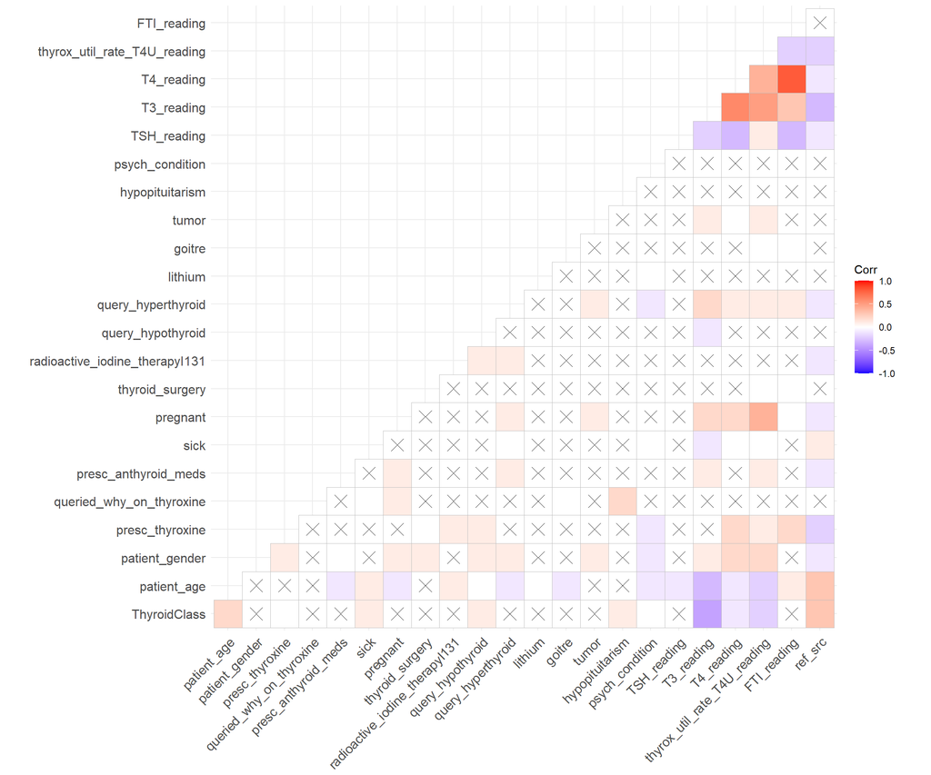

Les cases colorées indiquent les corrélations significatives. Les taux d’hormones sont, comme attendu, corrélés entre eux.

Data summary

| Name | raw |
| --- | --- |
| Number of rows | 3772 |
| Number of columns | 28 |
| _______________________ |  |
| Column type frequency: |  |
| character | 2 |
| numeric | 26 |
| ________________________ |  |
| Group variables | None |

**Variable type: character**

| skim_variable | n_missing | complete_rate | min | max | empty | n_unique | whitespace |
| --- | --- | --- | --- | --- | --- | --- | --- |
| ThyroidClass | 0 | 1 | 4 | 8 | 0 | 2 | 0 |
| ref_src | 1 | 1 | 3 | 5 | 0 | 5 | 0 |

**Variable type: numeric**

| skim_variable | n_missing | complete_rate | mean | sd | p0 | p25 | p50 | p75 | p100 | hist |
| --- | --- | --- | --- | --- | --- | --- | --- | --- | --- | --- |
| patient_age | 2 | 1.00 | 51.64 | 18.98 | 1.00 | 36.00 | 54.00 | 67.00 | 94.00 | ▁▆▆▇▂ |
| patient_gender | 0 | 1.00 | 0.66 | 0.47 | 0.00 | 0.00 | 1.00 | 1.00 | 1.00 | ▅▁▁▁▇ |
| presc_thyroxine | 0 | 1.00 | 0.12 | 0.33 | 0.00 | 0.00 | 0.00 | 0.00 | 1.00 | ▇▁▁▁▁ |
| queried_why_on_thyroxine | 0 | 1.00 | 0.01 | 0.11 | 0.00 | 0.00 | 0.00 | 0.00 | 1.00 | ▇▁▁▁▁ |
| presc_anthyroid_meds | 0 | 1.00 | 0.01 | 0.11 | 0.00 | 0.00 | 0.00 | 0.00 | 1.00 | ▇▁▁▁▁ |
| sick | 0 | 1.00 | 0.04 | 0.19 | 0.00 | 0.00 | 0.00 | 0.00 | 1.00 | ▇▁▁▁▁ |
| pregnant | 0 | 1.00 | 0.01 | 0.12 | 0.00 | 0.00 | 0.00 | 0.00 | 1.00 | ▇▁▁▁▁ |
| thyroid_surgery | 0 | 1.00 | 0.01 | 0.12 | 0.00 | 0.00 | 0.00 | 0.00 | 1.00 | ▇▁▁▁▁ |
| radioactive_iodine_therapyI131 | 0 | 1.00 | 0.02 | 0.12 | 0.00 | 0.00 | 0.00 | 0.00 | 1.00 | ▇▁▁▁▁ |
| query_hypothyroid | 0 | 1.00 | 0.06 | 0.24 | 0.00 | 0.00 | 0.00 | 0.00 | 1.00 | ▇▁▁▁▁ |
| query_hyperthyroid | 0 | 1.00 | 0.06 | 0.24 | 0.00 | 0.00 | 0.00 | 0.00 | 1.00 | ▇▁▁▁▁ |
| lithium | 0 | 1.00 | 0.00 | 0.07 | 0.00 | 0.00 | 0.00 | 0.00 | 1.00 | ▇▁▁▁▁ |
| goitre | 0 | 1.00 | 0.01 | 0.09 | 0.00 | 0.00 | 0.00 | 0.00 | 1.00 | ▇▁▁▁▁ |
| tumor | 0 | 1.00 | 0.03 | 0.16 | 0.00 | 0.00 | 0.00 | 0.00 | 1.00 | ▇▁▁▁▁ |
| hypopituitarism | 0 | 1.00 | 0.00 | 0.02 | 0.00 | 0.00 | 0.00 | 0.00 | 1.00 | ▇▁▁▁▁ |
| psych_condition | 0 | 1.00 | 0.05 | 0.22 | 0.00 | 0.00 | 0.00 | 0.00 | 1.00 | ▇▁▁▁▁ |
| TSH_measured | 0 | 1.00 | 0.90 | 0.30 | 0.00 | 1.00 | 1.00 | 1.00 | 3.30 | ▁▇▁▁▁ |
| TSH_reading | 369 | 0.90 | 5.09 | 24.52 | 0.00 | 0.50 | 1.40 | 2.70 | 530.00 | ▇▁▁▁▁ |
| T3_measured | 0 | 1.00 | 0.80 | 0.40 | 0.00 | 1.00 | 1.00 | 1.00 | 1.80 | ▂▁▇▁▁ |
| T3_reading | 769 | 0.80 | 2.01 | 0.83 | 0.05 | 1.60 | 2.00 | 2.40 | 10.60 | ▇▅▁▁▁ |
| T4_measured | 0 | 1.00 | 0.97 | 1.78 | 0.00 | 1.00 | 1.00 | 1.00 | 109.00 | ▇▁▁▁▁ |
| T4_reading | 231 | 0.94 | 108.29 | 35.65 | 1.00 | 87.00 | 103.00 | 124.00 | 430.00 | ▂▇▁▁▁ |
| thyrox_util_rate_T4U_measured | 0 | 1.00 | 0.90 | 0.30 | 0.00 | 1.00 | 1.00 | 1.00 | 1.00 | ▁▁▁▁▇ |
| thyrox_util_rate_T4U_reading | 387 | 0.90 | 1.00 | 0.20 | 0.25 | 0.88 | 0.98 | 1.08 | 2.32 | ▁▇▂▁▁ |
| FTI_measured | 0 | 1.00 | 0.93 | 1.95 | 0.00 | 1.00 | 1.00 | 1.00 | 119.00 | ▇▁▁▁▁ |
| FTI_reading | 386 | 0.90 | 110.47 | 33.09 | 2.00 | 93.00 | 107.00 | 124.00 | 395.00 | ▁▇▁▁▁ |

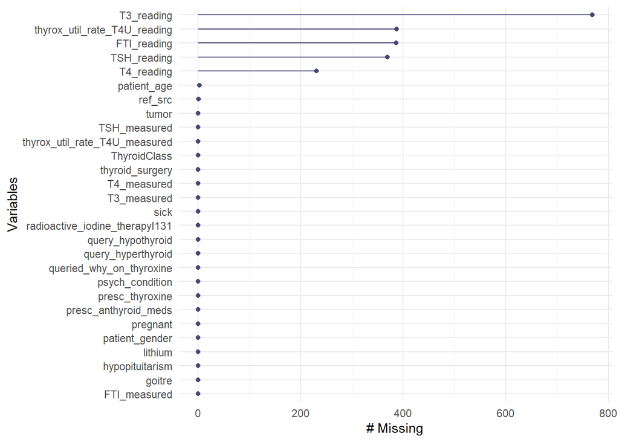

Les méthodes les plus courantes pour remplir des données manquantes sont de mettre 0, de remplir par la moyenne de la colonne ou bien d’utiliser l’algorithme *knn*.

Mettre 0 n’aurait pas de sens ici, et remplir par la moyenne nous a semblé être trop grossier. Nous avons préféré utiliser la méthodes *knn* du package **simputation**, dans l’idée que des patients aux caractéristiques similaires devraient présenter des taux similaires.

La méthode *knn* a de plus certains avantages. Elle n’est pas négativement impactée par l’utilisation de variables corrélées en tant que prédicteur, et de plus elle est capable de gérer la présence de données manquantes au sein des prédicteurs, la rendant particulièrement adaptée à notre situation. Ci-dessous les résultats graphiques de l’imputation.

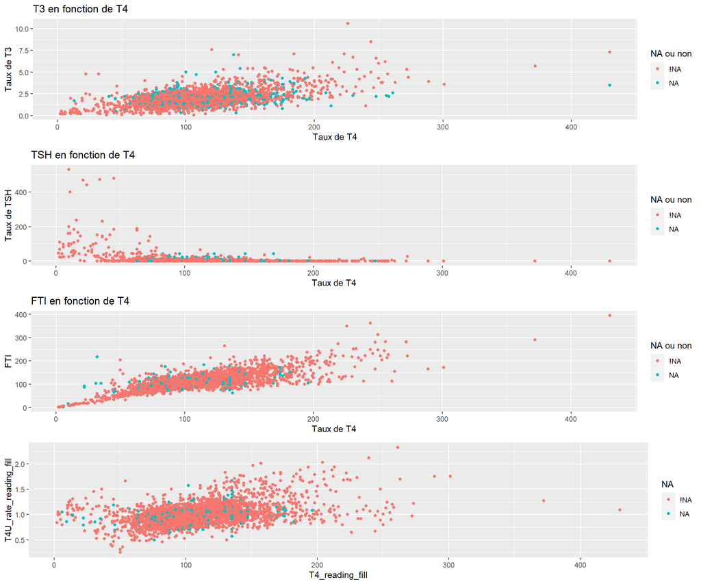

Les données imputées semblent se distribuer de la même façon que les données réelles.

# III. Le dashboard

Le dashboard doit fonctionner avec nos données modifiées. Les packages DT et ggradar sont nécessaires.

Notre dashboard est constitué de trois pages :

1. la première est un récapitulatif des informations de chaque patient. Chaque patient est identifié par un numéro qui correspond au numéro de sa ligne dans le dataset. L’utilisateur peut sélectionner dans la sidebar le numéro voulu.
2. la seconde contient un résumé des données du dataset.
3. la troisième permet de visualiser les données sous forme de graphique, de radar ou de boxplot. La variable X et Y du graphique sont au choix de l’utilisateur. De même, l’utilisateur peut choisir le facteur d’influence qu’il souhaite observer dans le graphique. Ce facteur d’influence choisi est décrit par le radar chart. Les variables X et Y sont décrites par les boxplots.

# IV. Analyse des données

Lors d’une maladie de la thyroïde, de nombreux symptômes peuvent apparaître. Dans le cas d’une hyperthyroïde (excès d’hormones thyroïdiennes), on observe chez le patient une anxiété, une irritabilité, une perte de poids, et des problèmes de visions. En cas d’hypothyroïde (manque d’hormones thyroîdiennes), on observe chez le patient une sensation de fatigue, une prise de poids, une voix rauque, et une sensibilité accrue au froid. La première étape pour détecter une potentielle maladie de la thyroïde serait donc d’observer ces symptômes.

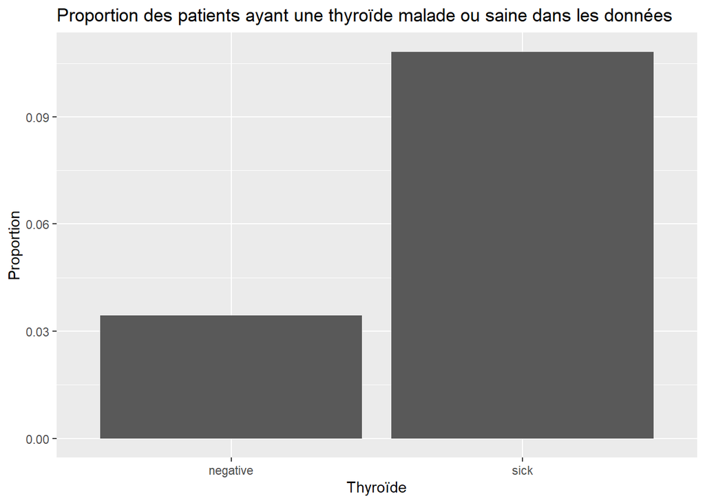

Comme on peut le voir ci-dessus, la proportion de gens présentant une maladie est plus importante dans la population diagnostiquée malade de la thyroïde.

Observons à présent la proportion d’autres caractéristiques telles que la chirurgie, le goitre, ou encore une tumeur.

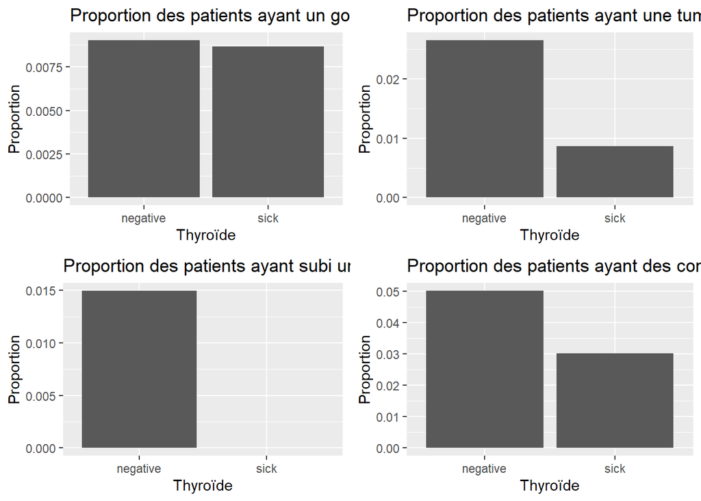

Même si de nombreuses personnes atteintes d’hyperthyroïde ont tendance à développer un goitre, le goitre peut aussi apparaître en cas de carences alimentaires, par exemple. De même, comme le montre les graphes ci-dessus, les patients malades n’ont pas plus de tumeur, de chirurgue, ou de condition psychologique que les patients non malades.

Aucune de ces quatre variables (**goitre**, **thyroid_surgery**, **tumor**, **psy_condition**) ne semble donc être un indicateur adapté d’une maladie de la thyroïde.

Cela correspond aux informations fournies par la matrice de corrélation présentée plus haut. Il n’y avait aucune corrélation (linéaire) significative entre la variable ThyroidClass et les variables goitre, tumor, thyroid_surgery et psy_condition.

Intéressons-nous à présent aux hormones. En cas de suspicion d’hyperthyroïde ou d’hypothyroïde, les médecins réalisent généralement un bilan sanguin, et examinent les taux de TSH, de T3 et de T4, afin de détecter de potentielles anomalies.

C’est le taux de TSH en priorité observé. Le taux de TSH doit normalement se trouver entre 0.35 - 5 mU/L. (On suppose ici que les données ont bel et bien cette unité). Les lignes horizontales indiquent le domaine normal du taux de TSH. On utilisera le logarithme des données pour faciliter leur exploitation.

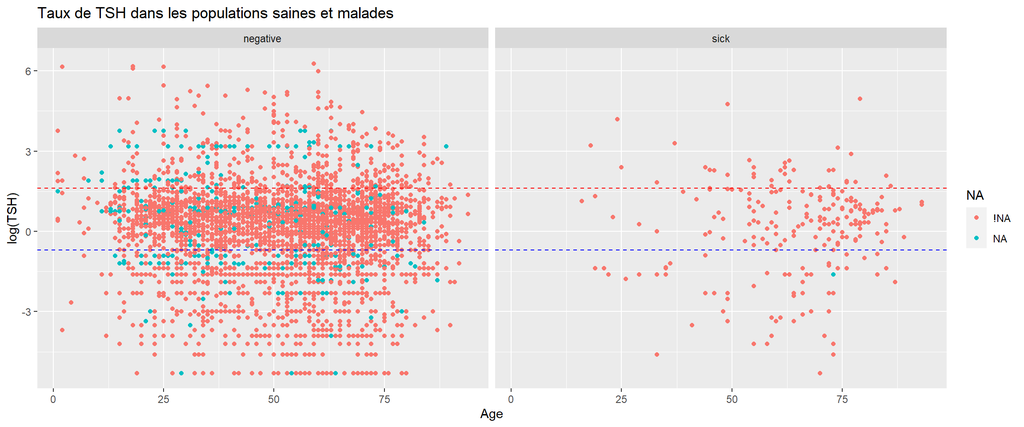

Que ce soit parmi les patients malades ou sains, le taux de TSH évolue beaucoup, y compris hors des bornes habituelles. Certaines valeurs de TSH pour des patients sains sont particulièrement élevées. Sans savoir si ces données sont correctes ou non, il est compliqué de faire confiance au calcul de la variance et de la moyenne pour les deux groupes : les données très élevées chez des gens sains impactent significativement les résultats.

Comparons les niveaux de TSH et de T4. En ce qui concerne les taux de T4, un taux normal se situe environ entre 50 et 150 nmol/L (ici encore les données semblent avoir cette unité). Les lignes horizontales et verticales correspondent respectivement aux taux normaux de T4 et de TSH.

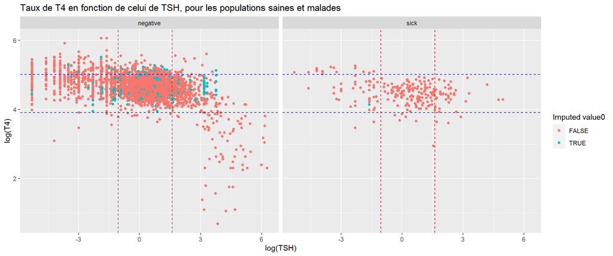

L’essentiel des données, dans les deux groupes, sont comprises dans les intervalles de référence. Il semble difficile d’observer de façon franche un comportement différent entre les deux groupes.

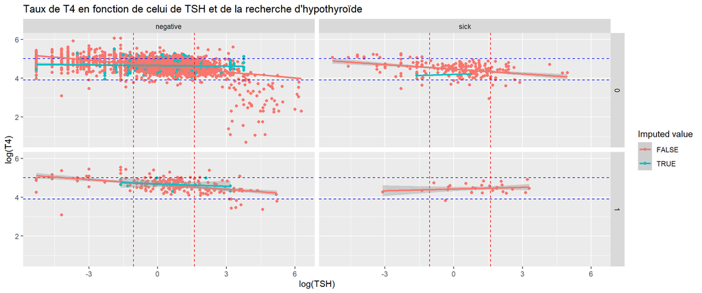

Comme on peut le voir ci-dessus, parmi les patients malades, une suspicion d’hypothyroïde correspond à un taux de TSH un peu trop élevé pour des taux de T4 normaux. Cela correspond bien à une hypothyroïde. (voir [Lien](https://www.uclahealth.org/medical-services/surgery/endocrine-surgery/conditions-treated/thyroid/normal-thyroid-hormone-levels)). En revanche, un grand nombre de patient déclarés sains et dont les taux d’hormones varient ont également une supicion d’hypothyroïde.La variable **query_hypothyroid** ne semble pas totalement adaptée à détecter une maladie.

Les autres facteurs (traitement au lithium, iodine radioactive, anti-thyroïdes, thyroxine) ne semblent pas permettre de détecter la maladie (trop peu de données pour mettre en évidence des comportements).

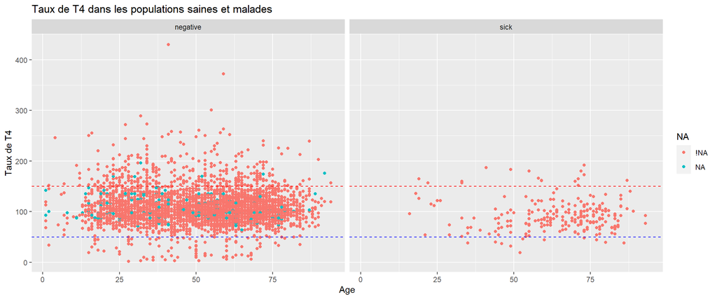

Les niveaux de T4 seuls ne mettent pas en évidence une différence de comportement marquée entre les 2 groupes.

Qu’en est-il de l’hormone T3 ? Les niveaux de T3 sont généralement compris entre 0.8 et 2.5 nmol/L.

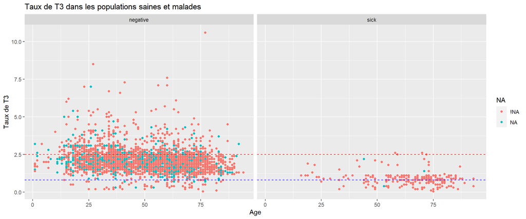

C’est ici plus probant : chez les personnes malades, les niveaux de T3 sont bien plus bas, comme confirmé par le boxplot ci-dessous :

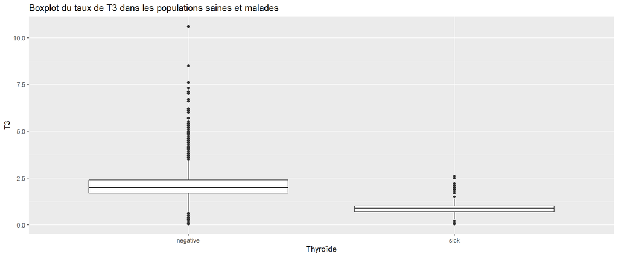

Visuellement, l’étude du FTI et du taux d’utilisation de T4 n’apporte pas beaucoup d’information. Néanmoins, si on regarde le boxplot du taux d’utilisation de T4 ci-dessous, celui-ci semble en moyenne plus bas chez les patients malades que chez les patients sains. Cela pourrait s’expliquer par un manque d’hormones T4 initial.

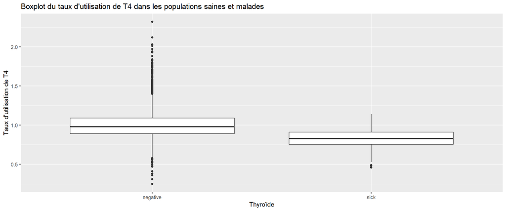

# V. Conclusion

En conclusion, le jeu de donnée ne semble pas simple à exploiter. Néanmoins, les variables qui varient le plus significativement entre les patients sains et malades semble être l’existence de symptômes et le taux d’hormone T3. Cela semble logique : pour diagnostiquer une maladie de la thyroïde, on observe dans un premier temps les symptômes, puis on prescrit un bilan sanguin.